# TFM

Nadia Moltó

8/2/2021

Inicialmente disponemos de varios ficheros: - Clinical data: Aqui aparecen los identificadores del paciente asi como sus datos clinicos (tipo de cancer, edad de deteccion,etc). -Mutations: Aqui se relaciona cada paciente con cada gen y se indica si tiene mutacion en cada uno de los genes (missense and nosense SNV). SNV es variacion en un unico nucleotido, missense es que se modifica un nucleotido de un codon que ahora codifica para otra proteina y nosense es que la modificacion de este codon produce un stop. -Tumormap relaciona los identificadores de los pacientes de los dos archivos anteriores.

```r
#Activacion de las librerias a emplear
library(survival)
library(rms)
```

```r
library(survplot)
library(Hmisc)
library(survminer)
require(ggplot2)


setwd("C:/Users/nadia/Desktop/TFM/DATOS") #Directorio donde estan los archivos de METABRIC

dc <- read.table("clinical_data.txt", header=T, sep="\t", quote="") #Cargar datos clinicos

#Exploracion de los datos:

dim(dc)#Numero de pacientes(filas) y variables (columnas)
```

```
## [1] 1980   35
```

```r
head(dc) #Primeras filas
```

|  | METABRIC.ID | MATCHED.NORMAL.METABRIC.ID | Cohort | Age.At.Diagnosis | Breast.Tumour.Laterality | Date.Of.Diagnosis | Last.Followup.Status | NPI | ER.Status | Inferred.Menopausal.State | Lymph.Nodes.Positive | Breast.Surgery | CT | HT | RT | Grade | Size | Histological.Type | Stage | Cellularity | DeathBreast | Death | T | TLR | LR | TDR | DR | HER2.SNP6 | iC10 | … |
| --- | --- | --- | --- | --- | --- | --- | --- | --- | --- | --- | --- | --- | --- | --- | --- | --- | --- | --- | --- | --- | --- | --- | --- | --- | --- | --- | --- | --- | --- | --- |
| 1 | MB-0002 | MB-0003 | 1 | 43.19 | r | 2000/12 | a | 4.020 | pos | pre | 0 | BREAST CONSERVING | NO/NA | TAM | CW | 3 | 10 | IDC | 1 | high | 0 | 0 | 2539 | 2539 | 0 | 2539 | 0 | NEUT | 4ER+ | … |
| 2 | MB-0005 | MB-0004 | 1 | 48.87 | r | 2001/02 | d-d.s. | 4.030 | pos | pre | 1 | MASTECTOMY | OTHER | TAM | NO/NA | 2 | 15 | IDC | 2 | high | 1 | 1 | 4911 | 4911 | 0 | 4599 | 1 | NEUT | 3 | … |
| 3 | MB-0006 | MB-0007 | 1 | 47.68 | r | 2001/02 | a | 4.050 | pos | pre | 3 | MASTECTOMY | OTHER | AI | CW | 2 | 25 | IDC | 2 | moderate | 0 | 0 | 4948 | 4948 | 0 | 4948 | 0 | NEUT | 9 | … |
| 4 | MB-0010 | MB-0011 | 1 | 78.77 | l | 2001/03 | d-d.s. | 4.062 | pos | post | 0 | MASTECTOMY | NO/NA | TAM | CW | 3 | 31 | IDC | 4 | moderate | 1 | 1 | 234 | 234 | 0 | 88 | 1 | NEUT | 7 | … |
| 5 | MB-0014 | MB-0015 | 1 | 56.45 | r | 2001/04 | a | 4.020 | pos | post | 1 | BREAST CONSERVING | AC | TAM | CW | 2 | 10 | IDC | 2 | moderate | 0 | 0 | 4930 | 4930 | 0 | 4930 | 0 | LOSS | 3 | … |
| 6 | MB-0020 | MB-0021 | 1 | 70.00 | l | 2001/03 | d-d.s. | 6.130 | neg | post | 7 | MASTECTOMY | CMF | NO/NA | CW-NODAL | 3 | 65 | ILC | 3 | high | 1 | 1 | 672 | 672 | 0 | 357 | 1 | NEUT | 4ER- | … |

```r
names(dc) #Nombres de las variables
```

```
##  [1] "METABRIC.ID"                "MATCHED.NORMAL.METABRIC.ID"
##  [3] "Cohort"                     "Age.At.Diagnosis"
##  [5] "Breast.Tumour.Laterality"   "Date.Of.Diagnosis"
##  [7] "Last.Followup.Status"       "NPI"
##  [9] "ER.Status"                  "Inferred.Menopausal.State"
## [11] "Lymph.Nodes.Positive"       "Breast.Surgery"
## [13] "CT"                         "HT"
## [15] "RT"                         "Grade"
## [17] "Size"                       "Histological.Type"
## [19] "Stage"                      "Cellularity"
## [21] "DeathBreast"                "Death"
## [23] "T"                          "TLR"
## [25] "LR"                         "TDR"
## [27] "DR"                         "HER2.SNP6"
## [29] "iC10"                       "Pam50Subtype"
## [31] "ER.Expr"                    "Her2.Expr"
## [33] "PR.Expr"                    "ClaudinSubtype"
## [35] "Complete.Rec.History"
```

```r
summary(dc$Age.At.Diagnosis) #Estadisticas basicas
```

```
##    Min. 1st Qu.  Median    Mean 3rd Qu.    Max.
##   21.93   51.42   61.80   61.09   70.60   96.29
```

```r
dm <- read.csv2("mutations.csv", header=T) #Lectura datos de mutaciones

#en este caso los datos viene transpuestos (individuos en columnas y genes en filas)
#Hay que transponer la tabla con la funcion t()
dm <- t(dm)
#si hacemos
head(dm)[1:5, 1:5]
```

```
##           [,1]   [,2]   [,3]     [,4]     [,5]
## ID        "AKT1" "AKT2" "PIK3CA" "PIK3R1" "PTEN"
## MTS.T0001 NA     NA     NA       NA       NA
## MTS.T0002 NA     NA     NA       NA       NA
## MTS.T0003 NA     NA     NA       NA       NA
## MTS.T0004 NA     NA     NA       NA       NA
```

```r
#observamos que la operacion no se ha hecho bien ya que el nombre de los genes no aparece como nombres sino en la primera fila de la tabla, por lo tanto:

colnames(dm) <- dm[1,] #Copiamos la primera fila como nombres de columnas
dm <- dm[-1, ] #Eliminamos la primera fila ya que ya no la necesitamos
dm <- as.data.frame(dm) #Convertimos la tabla a dataframe para operar mejor con ella
dm$sample <- as.character(row.names(dm)) #Creamos una columna con los identificadores tumorales
head(dm)[,1:10] # Muestra encabezado (primeras filas) para las primeras 10 columnas
```

|  | AKT1 | AKT2 | PIK3CA | PIK3R1 | PTEN | CCND3 | CDKN1B | CDKN2A | RB1 | ARID1A |
| --- | --- | --- | --- | --- | --- | --- | --- | --- | --- | --- |
| MTS.T0001 | NA | NA | NA | NA | NA | NA | NA | NA | NA | NA |
| MTS.T0002 | NA | NA | NA | NA | NA | NA | NA | NA | NA | NA |
| MTS.T0003 | NA | NA | NA | NA | NA | NA | NA | NA | NA | NA |
| MTS.T0004 | NA | NA | NA | NA | NA | NA | NA | NA | NA | NA |
| MTS.T0005 | NA | NA | NA | NA | NA | NA | NA | NA | NA | NA |
| MTS.T0006 | NA | NA | missense_snv_recurrent | NA | NA | NA | NA | NA | NA | NA |

```r
head(dm)[,165:174] # Muestra encabezado para las ultimas 10 columnas (columna creada)
```

|  | USP9X | TBL1XR1 | MAGEA8 | CLRN2 | DCAF4L2 | FRMD3 | THADA | DTWD2 | APC | sample |
| --- | --- | --- | --- | --- | --- | --- | --- | --- | --- | --- |
| MTS.T0001 | NA | NA | NA | NA | NA | NA | NA | NA | NA | MTS.T0001 |
| MTS.T0002 | NA | NA | NA | NA | NA | NA | NA | NA | NA | MTS.T0002 |
| MTS.T0003 | NA | NA | NA | NA | NA | NA | NA | NA | NA | MTS.T0003 |
| MTS.T0004 | NA | NA | NA | NA | NA | NA | NA | NA | NA | MTS.T0004 |
| MTS.T0005 | NA | NA | NA | NA | NA | NA | NA | NA | missense_snv | MTS.T0005 |
| MTS.T0006 | NA | NA | NA | NA | NA | NA | NA | NA | NA | MTS.T0006 |

```r
#Podemos ver que en los datos clinicos los identificadores (de pacientes) son del tipo
# MB-XXXX
#Mientras que en los datos de mutaciones los identificadores (de tumores) son del tipo
# MTS.TXXXX
#Por tanto necesitamos la tabla TumorMap.txt para establecer la correspondencia
tm <- read.table("tumorMap.txt", header=T, sep="\t") #Cargar tabla en variable

#Vamos a cruzar esta tabla con los datos clinicos usando la funcion merge()
#Es necesario especificar el nombre de la columna correspondiente de cada tabla con la cual queremos hacer la correspondencia (Metabric ID pero escrito de formas  diferentes en cada tabla)

dc_new <- merge(dc, tm, by.x="METABRIC.ID", by.y = "metabricId")
head (dc_new) #Para comprobar que la operacion se realizo correctamente
```

|  | METABRIC.ID | MATCHED.NORMAL.METABRIC.ID | Cohort | Age.At.Diagnosis | Breast.Tumour.Laterality | Date.Of.Diagnosis | Last.Followup.Status | NPI | ER.Status | Inferred.Menopausal.State | Lymph.Nodes.Positive | Breast.Surgery | CT | HT | RT | Grade | Size | Histological.Type | Stage | Cellularity | DeathBreast | Death | T | TLR | LR | TDR | DR | HER2.SNP6 | iC10 | … |
| --- | --- | --- | --- | --- | --- | --- | --- | --- | --- | --- | --- | --- | --- | --- | --- | --- | --- | --- | --- | --- | --- | --- | --- | --- | --- | --- | --- | --- | --- | --- |
| 1 | MB-0000 | NA | 1 | 75.65 | r | 2000/12 | a | 6.044 | pos | post | 10 | MASTECTOMY | NO/NA | TAM/AI | CW | 3 | 22 | IDC | 2 | NA | 0 | 0 | 4215 | 4215 | 0 | 4215 | 0 | NEUT | 4ER+ | … |
| 2 | MB-0002 | MB-0003 | 1 | 43.19 | r | 2000/12 | a | 4.020 | pos | pre | 0 | BREAST CONSERVING | NO/NA | TAM | CW | 3 | 10 | IDC | 1 | high | 0 | 0 | 2539 | 2539 | 0 | 2539 | 0 | NEUT | 4ER+ | … |
| 3 | MB-0005 | MB-0004 | 1 | 48.87 | r | 2001/02 | d-d.s. | 4.030 | pos | pre | 1 | MASTECTOMY | OTHER | TAM | NO/NA | 2 | 15 | IDC | 2 | high | 1 | 1 | 4911 | 4911 | 0 | 4599 | 1 | NEUT | 3 | … |
| 4 | MB-0006 | MB-0007 | 1 | 47.68 | r | 2001/02 | a | 4.050 | pos | pre | 3 | MASTECTOMY | OTHER | AI | CW | 2 | 25 | IDC | 2 | moderate | 0 | 0 | 4948 | 4948 | 0 | 4948 | 0 | NEUT | 9 | … |
| 5 | MB-0008 | NA | 1 | 76.97 | r | 2001/03 | d-d.s. | 6.080 | pos | post | 8 | MASTECTOMY | CAPE | TAM | CW-NODAL | 3 | 40 | IDC | 2 | high | 1 | 1 | 1241 | 564 | 1 | 941 | 1 | NEUT | 9 | … |
| 6 | MB-0010 | MB-0011 | 1 | 78.77 | l | 2001/03 | d-d.s. | 4.062 | pos | post | 0 | MASTECTOMY | NO/NA | TAM | CW | 3 | 31 | IDC | 4 | moderate | 1 | 1 | 234 | 234 | 0 | 88 | 1 | NEUT | 7 | … |

```r
#Ahora ya podemos cruzar las tablas con la informacion de mutaciones
#Sin embargo vemos que en la tabla dc_new los identificadores de tumores son de la forma
#MTS.TXXXX
#Mientras que en la tabla dm son de la forma MTS-TXXXX
#Vamos a modificar los nombres de la tabla dc_new sustituyendo el "-" por "."  con la
#funcion gsub
dc_new$sample <- gsub("-", ".", dc_new$sample)



data <- merge(dc_new, dm, by="sample") #Unir los datos en una misma tabla
```

```r
#Exploracion de los datos:
variables<- c("Numero de pacientes", "Edad media", "Desviacion estandar de la edad")
pacientes<-ncol(data)
edad.media<-mean(data$Age.At.Diagnosis)
desviacion.edad<-sd(data$Age.At.Diagnosis)
datos<-c(pacientes,edad.media,desviacion.edad)

tabla<-data.frame(cbind(variables,datos))
tabla
```

[output not shown]

Ahora ya tenemos la tabla creada con los datos y vamos a empezar a explorarla y extraer datos. Inicialmente, se van a aislar los genes que aparecen mutados en, al menos, el 10% de los pacientes

PAM50:

```r
table(data$Pam50Subtype)
```

```
##
##  Basal   Her2   LumA   LumB Normal
##    308    236    696    474    184
```

```r
###LumA
data_LumA <- subset(data, Pam50Subtype=="LumA") #Con esto estamos extrayendo para la clasificacion Pam50 los pacientes LumA
data_LumA <- data_LumA[,-c(1:37)] #Eliminar variables clinicas y sumar solo genes, 37 porque son las columnas con datos clinicos
suma_mutacionesLA <- apply(data_LumA,2,function(x){sum(!is.na(x))})/696 #Se eliminan los NA, se suman los datos y se normalizan los datos dividiendo por el numero de pacientes LumA
```

```r
#LumB
data_LumB <- subset(data, Pam50Subtype=="LumB") #Con esto estamos extrayendo para la clasificacion Pam50 los pacientes LumB
data_LumB <- data_LumB[,-c(1:37)]
suma_mutacionesLB <- apply(data_LumB,2,function(x){sum(!is.na(x))})/474
```

```r
#Basal
data_Basal <- subset(data, Pam50Subtype=="Basal")
data_Basal <- data_Basal[,-c(1:37)]
suma_mutacionesB <- apply(data_Basal,2,function(x){sum(!is.na(x))})/308
```

```r
#Normal
data_Normal <- subset(data, Pam50Subtype=="Normal")
data_Normal <- data_Normal[,-c(1:37)]
suma_mutacionesN <- apply(data_Normal,2,function(x){sum(!is.na(x))})/184
```

```r
#Her2
data_Her2 <- subset(data, Pam50Subtype=="Her2")
data_Her2 <- data_Her2[,-c(1:37)]
suma_mutacionesH <- apply(data_Her2,2,function(x){sum(!is.na(x))})/236
```

Representamos los genes mutados de forma diferencial en el 10% de los individuos para esta clasificacion:

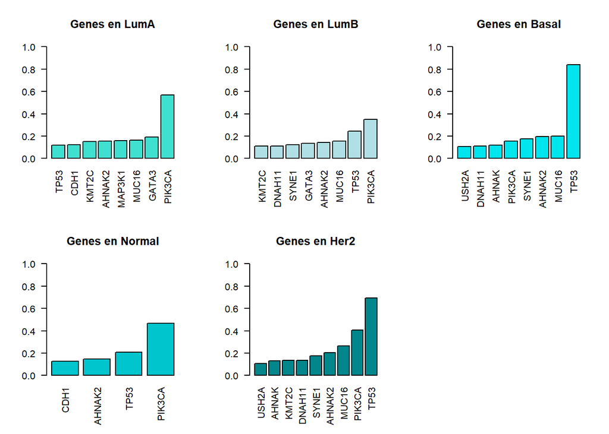

```r
par(mfrow=c(2,3))
barplot((sort(suma_mutacionesLA[which(suma_mutacionesLA>0.1)])), las=2, col="turquoise", main = "Genes en LumA",ylim=0:1)
barplot((sort(suma_mutacionesLB[which(suma_mutacionesLB>0.1)])), las=2, col = "powderblue", main = "Genes en LumB",ylim=0:1)
barplot((sort(suma_mutacionesB[which(suma_mutacionesB>0.1)])), las=2, col = "turquoise2", main = "Genes en Basal",ylim=0:1)
barplot((sort(suma_mutacionesN[which(suma_mutacionesN>0.1)])), las=2, col = "turquoise3", main = "Genes en Normal",ylim=0:1)
barplot((sort(suma_mutacionesH[which(suma_mutacionesH>0.1)])), las=2, col = "turquoise4", main = "Genes en Her2",ylim=0:1)
#Solo representamos aquellos genes que aparecen mutados en mas del 10% de los pacientes
```

Ahora miramos para otra clasificacion. Empezamos por la histologica:

```r
levels(data$Histological.Type) #Es necesario averiguar primero los niveles que hay en esta clasificacion
```

```
##  [1] "BENIGN"          "DCIS"            "IDC"             "IDC-MED"
##  [5] "IDC-MUC"         "IDC-TUB"         "IDC+ILC"         "ILC"
##  [9] "INVASIVE TUMOUR" "OTHER INVASIVE"  "PHYL"
```

```r
#Veamos cuantos pacientes tienen cada uno de los tipos
table(data$Histological.Type)
```

```
##
##          BENIGN            DCIS             IDC         IDC-MED         IDC-MUC
##               1               2            1503              31              42
##         IDC-TUB         IDC+ILC             ILC INVASIVE TUMOUR  OTHER INVASIVE
##              67              87             141               9              19
##            PHYL
##               0
```

Vamos a representar los genes mutados en el 10% de los pacientes que padecen cada subnivel de este cancer segun esta clasificacion:

En el caso del tipo “BENIGN” solo tenemos 1 paciente que lo padece, entonces aqui lo unico que podria verse es aquellos genes mutados que presenta este paciente.

```r
#BEnign
data_BENIGN <- subset(data, Histological.Type=="BENIGN")
data_BENIGN <- data_BENIGN[,-c(1:37)]
suma_mutacionesBENIGN <- apply(data_BENIGN,2,function(x){sum(!is.na(x))})
```

Ahora para el resto de subtipos de cancer dentro de esta clasificacion:

```r
data_DCIS <- subset(data, Histological.Type=="DCIS")
data_DCIS <- data_DCIS[,-c(1:37)]
suma_mutacionesDCIS <- apply(data_DCIS,2,function(x){sum(!is.na(x))})/2
data_IDC <- subset(data, Histological.Type=="IDC")
data_IDC <- data_IDC[,-c(1:37)]
suma_mutacionesIDC <- apply(data_IDC,2,function(x){sum(!is.na(x))})/1503
data_IDCMED <- subset(data, Histological.Type=="IDC-MED")
data_IDCMED <- data_IDCMED[,-c(1:37)]
suma_mutacionesIDCMED <- apply(data_IDCMED,2,function(x){sum(!is.na(x))})/31
data_IDCMUC <- subset(data, Histological.Type=="IDC-MUC")
data_IDCMUC <- data_IDCMUC[,-c(1:37)]
suma_mutacionesIDCMUC <- apply(data_IDCMUC,2,function(x){sum(!is.na(x))})/42
data_IDCTUB <- subset(data, Histological.Type=="IDC-TUB")
data_IDCTUB <- data_IDCTUB[,-c(1:37)]
suma_mutacionesIDCTUB <- apply(data_IDCTUB,2,function(x){sum(!is.na(x))})/67
data_IDCILC <- subset(data, Histological.Type=="IDC+ILC")
data_IDCILC <- data_IDCILC[,-c(1:37)]
suma_mutacionesIDCILC <- apply(data_IDCILC,2,function(x){sum(!is.na(x))})/87
data_ILC <- subset(data, Histological.Type=="ILC")
data_ILC <- data_ILC[,-c(1:37)]
suma_mutacionesILC <- apply(data_ILC,2,function(x){sum(!is.na(x))})/141
data_IT <- subset(data, Histological.Type=="INVASIVE TUMOUR")
data_IT <- data_IT[,-c(1:37)]
suma_mutacionesIT <- apply(data_IT,2,function(x){sum(!is.na(x))})/9
data_OI <- subset(data, Histological.Type=="OTHER INVASIVE")
data_OI <- data_OI[,-c(1:37)]
suma_mutacionesOI <- apply(data_OI,2,function(x){sum(!is.na(x))})/19
```

No hay ningun paciente con cancer filoides que presente alguna mutacion, por lo que no se representa este subtipo.

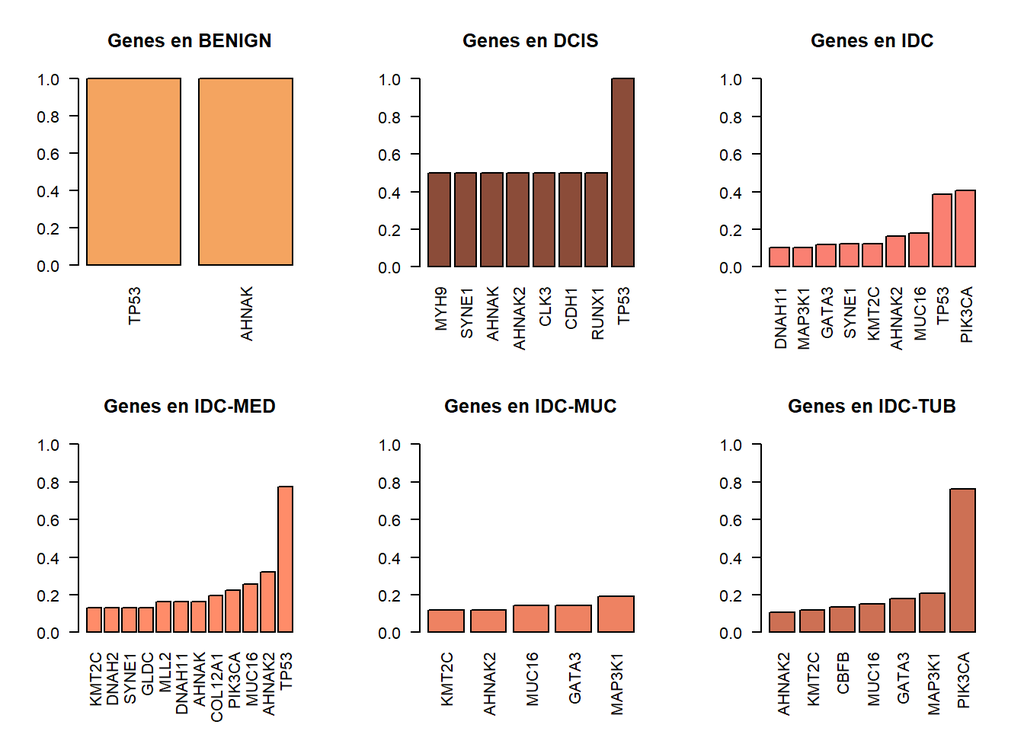

```r
#Representamos:
par(mfrow=c(2,3))
barplot((sort(suma_mutacionesBENIGN[which(suma_mutacionesBENIGN>0.1)])), las=2, col="sandybrown", main="Genes en BENIGN") #Aqui hay que tener en cuenta que solo hay un paciente con este tipo de tumor
barplot((sort(suma_mutacionesDCIS[which(suma_mutacionesDCIS>0.1)])), las=2, col="salmon4", main = "Genes en DCIS", ylim= 0:1)
barplot((sort(suma_mutacionesIDC[which(suma_mutacionesIDC>0.1)])), las=2, col="salmon", main = "Genes en IDC", ylim= 0:1)
barplot((sort(suma_mutacionesIDCMED[which(suma_mutacionesIDCMED>0.1)])), las=2, col="salmon1", main = "Genes en IDC-MED", ylim= 0:1)
barplot((sort(suma_mutacionesIDCMUC[which(suma_mutacionesIDCMUC>0.1)])), las=2, col="salmon2", main = "Genes en IDC-MUC", ylim= 0:1)
barplot((sort(suma_mutacionesIDCTUB[which(suma_mutacionesIDCTUB>0.1)])), las=2, col="salmon3", main = "Genes en IDC-TUB", ylim= 0:1)
```

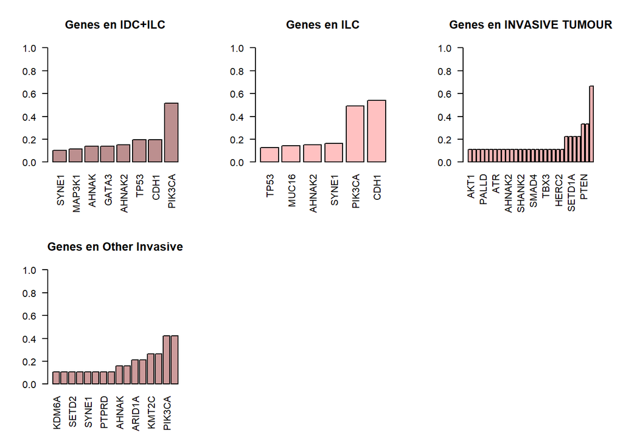

```r
par(mfrow=c(2,3))
barplot((sort(suma_mutacionesIDCILC[which(suma_mutacionesIDCILC>0.1)])), las=2, col="rosybrown", main = "Genes en IDC+ILC", ylim= 0:1)
barplot((sort(suma_mutacionesILC[which(suma_mutacionesILC>0.1)])), las=2, col="rosybrown1", main = "Genes en ILC", ylim= 0:1)
barplot((sort(suma_mutacionesIT[which(suma_mutacionesIT>0.1)])), las=2, col="rosybrown2", main = "Genes en INVASIVE TUMOUR", ylim= 0:1)
barplot((sort(suma_mutacionesOI[which(suma_mutacionesOI>0.1)])), las=2, col="rosybrown3", main = "Genes en Other Invasive", ylim= 0:1)
```

Claudin Subtype

```r
table(data$ClaudinSubtype) #Variables
```

```
##
##       Basal claudin-low        Her2        LumA        LumB      Normal
##         199         199         220         679         461         140
```

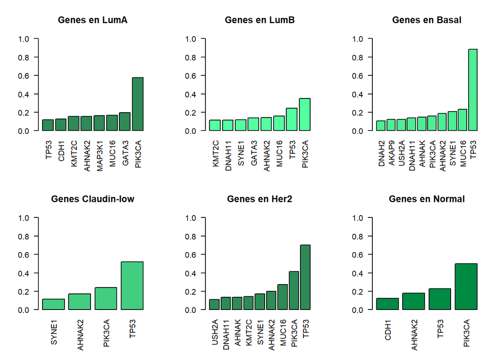

```r
#LumA
data_LumAc <- subset(data, ClaudinSubtype=="LumA")
data_LumAc <- data_LumAc[,-c(1:37)]
suma_mutacionesLAc <- apply(data_LumAc,2,function(x){sum(!is.na(x))})/679
#LumB
data_LumBc <- subset(data, ClaudinSubtype=="LumB")
data_LumBc <- data_LumBc[,-c(1:37)]
suma_mutacionesLBc <- apply(data_LumBc,2,function(x){sum(!is.na(x))})/461
#Basal
data_Basalc <- subset(data, ClaudinSubtype=="Basal")
data_Basalc <- data_Basalc[,-c(1:37)]
suma_mutacionesBc <- apply(data_Basalc,2,function(x){sum(!is.na(x))})/199
#Claudin low
data_clau <- subset(data, ClaudinSubtype=="claudin-low")
data_clau <- data_clau[,-c(1:37)]
suma_mutacionesclau <- apply(data_clau,2,function(x){sum(!is.na(x))})/199
#Her2
data_Her2c <- subset(data, ClaudinSubtype=="Her2")
data_Her2c <- data_Her2c[,-c(1:37)]
suma_mutacionesHer2c <- apply(data_Her2c,2,function(x){sum(!is.na(x))})/220
#Normal
data_Normalc<- subset(data, ClaudinSubtype=="Normal")
data_Normalc <- data_Normalc[,-c(1:37)]
suma_mutacionesNormalc <- apply(data_Normalc,2,function(x){sum(!is.na(x))})/140

#Representamos
par(mfrow=c(2,3))
barplot((sort(suma_mutacionesLAc[which(suma_mutacionesLAc>0.1)])), las=2,col="seagreen", main = "Genes en LumA", ylim= 0:1)
barplot((sort(suma_mutacionesLBc[which(suma_mutacionesLBc>0.1)])), las=2, col="seagreen1", main = "Genes en LumB", ylim= 0:1)
barplot((sort(suma_mutacionesBc[which(suma_mutacionesBc>0.1)])), las=2, col="seagreen2", main = "Genes en Basal", ylim= 0:1)
barplot((sort(suma_mutacionesclau[which(suma_mutacionesclau>0.1)])), las=2, col="seagreen3", main = "Genes Claudin-low", ylim= 0:1)
barplot((sort(suma_mutacionesHer2c[which(suma_mutacionesHer2c>0.1)])), las=2, col="seagreen4", main = "Genes en Her2", ylim= 0:1)
barplot((sort(suma_mutacionesNormalc[which(suma_mutacionesNormalc>0.1)])), las=2, col="springgreen4", main = "Genes en Normal", ylim= 0:1)
```

ER, PR, HER2

```r
table(data$ER.Expr)
```

```
##
##    -    +
##  445 1459
```

```r
table(data$PR.Expr)
```

```
##
##    -    +
##  895 1009
```

```r
table(data$Her2.Expr)
```

```
##
##    -    +
## 1668  236
```